# Transport 2: Details on different Mechanisms

Jeffrey A. Walker

04 October, 2021

# Simple diffusion

There is no membrane protein that helps the transport!

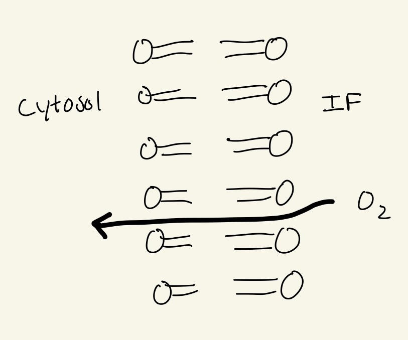

# Channels

A membrane protein that acts somewhat like a pore or window but *is specific* to species. Generally these are ion channels but H2O also is transported by water channels called aquaporins.

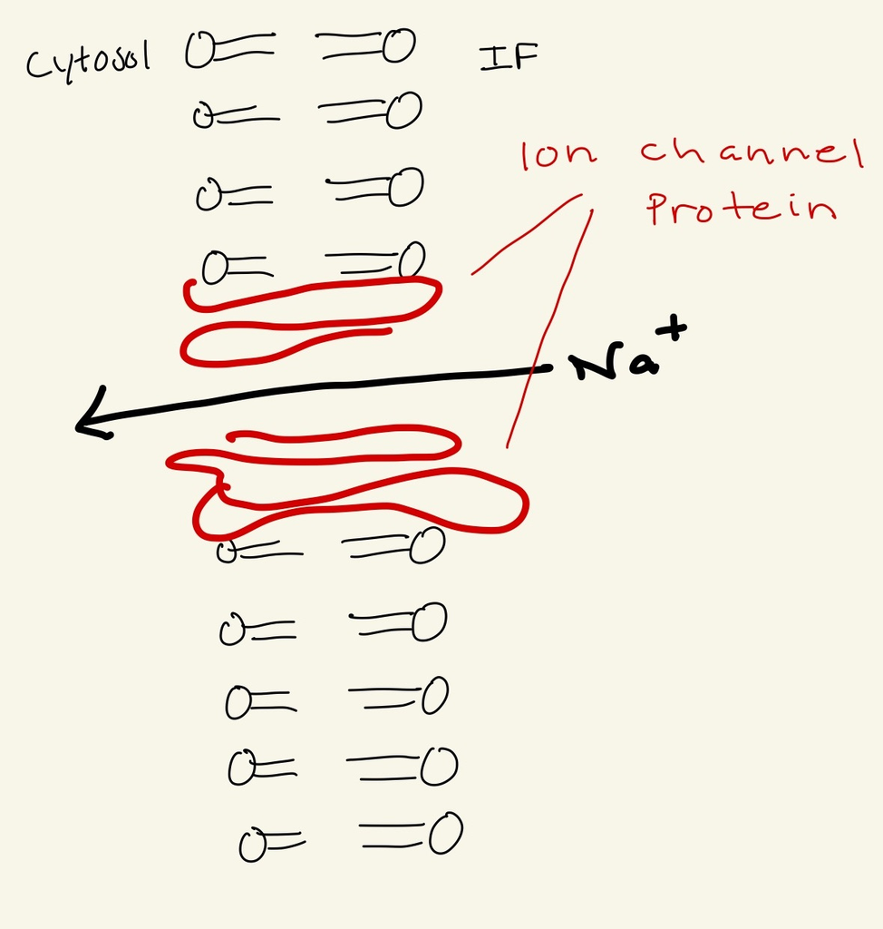

# Transporters

Membrane protiens that bind to the molecule. This binding causes the protein to change shape (**conformational change**) which has the consequence of moving the molecule to the opposite side of the membrane.

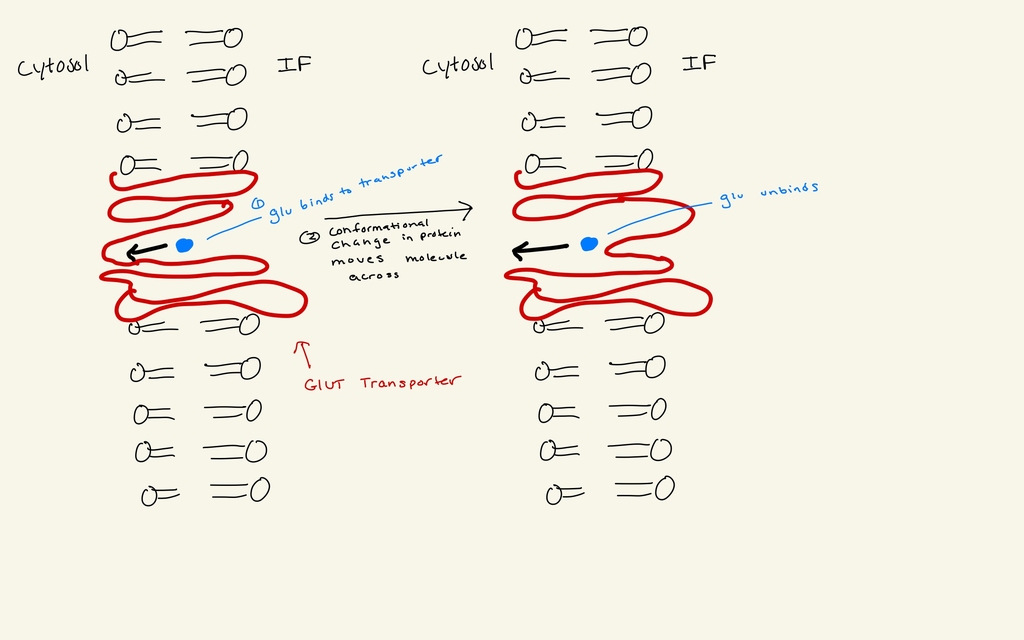

# Primary active transport – pumps

Active transport is *up a concentration gradient*. In primary active transport, the membrane protein that transports the molecule is also the membrane protein that functions as an enzyme and transfers energy from some donor (such as ATP) to the transport.

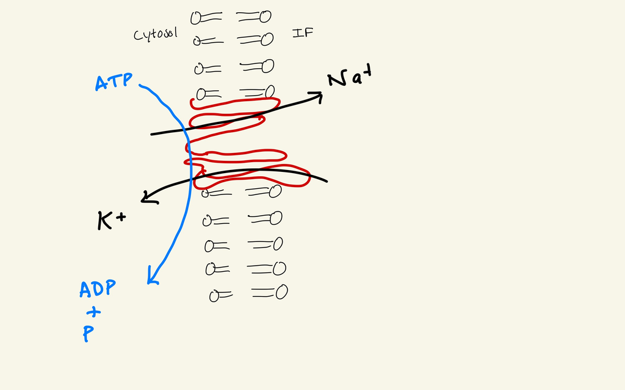

# Secondary active transport

Secondary active transport requires two membrane proteins. One to create an ion gradient (usually either a Na+ or a H+ gradient). The second to transport the molecule up it’s chemical gradint. A classic example is the epithelium of the proximal tubule in the kidney. The lumen side is what will become urine. We need to recover stuff in this lumen and not lose it in our urine. The problem is that to recover glucose (and other molecules), the concentration gradient is uphill, so external energy needs to be used. This energy comes from a Na+ ion gradient across the **apical membrane** (lumen side of cell). The Na+ ion gradient comes from Na+ pump on the **basal membrane** (IF side of cell).

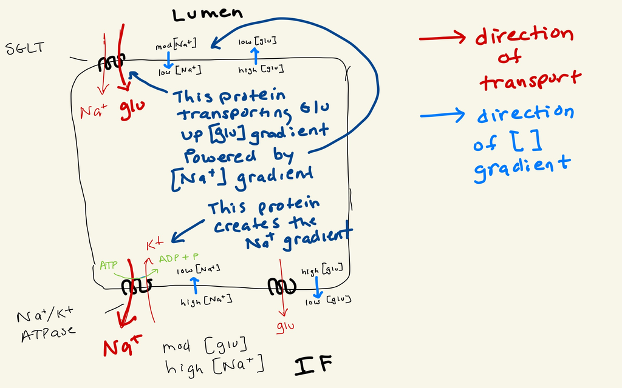

Only the transport of glucose across the apical membrane is secondary active transport. But I show the Na+/K+ pump because it is necessary for this transport. And I show the glucose transporter on the basal membrane, because this is how glucose is secreted by the cell into the blood. So, the image is complex because lots of different transport mechanisms are occurring, including

1. Na+ is pumped across the basal membrane by primary active transport (Na+/K+ pump)
2. K+ is pumped across the basal membrane by primary active transport (Na+/K+ pump)
3. Na+ is transported across the apical membrane by passive transport (sodium dependent glucose transporter SGLT)
4. glucose is transported across the apical membrane by secondary active transport (sodium dependent glucose transporter SGLT)
5. glucose is transported across the basal membrane by passive transport (glucose transporter GLUT).